# Bias of Gradient in Stochastic Gradient Descent (SGD)

We are interested in if the gradient of a mini-batch in SGD is biased, compared to the full gradient of the dataset. Specifically, $\forall \theta \in \Theta$, does

\begin{equation} \frac{1}{m} E( \nabla L(X_m, Y_m, \theta) ) = \frac{1}{n} \nabla L(X_n, Y_n, \Theta)? \end{equation}

```python
import gpytorch
import torch
import numpy as np
import random
import warnings
import matplotlib.pyplot as plt
from tqdm import tqdm

import pdb

random.seed(123)
np.random.seed(123)
```

# Model and Helpers

```python
# Simple Model From GPyTorch Regression Tutorial
class ExactGPModel(gpytorch.models.ExactGP):

    def __init__(self, train_x, train_y, likelihood):
        super(ExactGPModel, self).__init__(train_x, train_y, likelihood)
        self.mean_module = gpytorch.means.ConstantMean()
        self.covar_module = gpytorch.kernels.ScaleKernel(gpytorch.kernels.RBFKernel())

    def forward(self, x):
        mean_x = self.mean_module(x)
        covar_x = self.covar_module(x)
        return gpytorch.distributions.MultivariateNormal(mean_x, covar_x)

    def set_parameters(self, noise = None, outputscale = None, lengthscale = None):
        if noise is not None:
            self.likelihood.noise_covar.noise = noise**2
        if outputscale is not None:
            self.covar_module.outputscale = outputscale**2
        if lengthscale is not None:
            self.covar_module.base_kernel.lengthscale = lengthscale

# Container for model, likelihood, mll, and optimizer
class SuperModel:

    def __init__(self, X, Y):
        # Model and likelihood
        self.likelihood = gpytorch.likelihoods.GaussianLikelihood()
        self.model = ExactGPModel(X, Y, self.likelihood)
        # Loss
        self.mll = gpytorch.mlls.ExactMarginalLogLikelihood(self.likelihood, self.model)
        # For zero-ing gradients
        self.optimizer = torch.optim.Optimizer(self.model.parameters(), {})
        # 'Eval' mode since we will never be training
        self.model.eval()
        self.likelihood.eval()

    # 'True' gradient at current parameter values
    def gradient(self, X, Y):
        with gpytorch.settings.fast_pred_var(), gpytorch.settings.max_cholesky_size(n + 1):
            self.optimizer.zero_grad()
            with warnings.catch_warnings():
                warnings.simplefilter("ignore")
                preds = self.model(X)
            loss = -self.mll(preds, Y)
            loss.backward()
        nL = torch.cat([torch.flatten(param.grad) for _, param in self.model.named_parameters()])
        return nL

    # Mini-batch
    def mini_gradient(self, X, Y, m = 10, k = 1000):
        nLms = []
        for _ in range(k):
            minibatch = np.random.choice(X.shape[0], m, replace = False)
            with gpytorch.settings.fast_pred_var(), gpytorch.settings.max_cholesky_size(k + 1):
                self.optimizer.zero_grad()
                output = self.model(X[minibatch])
                loss = -self.mll(output, Y[minibatch])
                loss.backward()
            nLm = torch.cat([torch.flatten(param.grad) for _, param in self.model.named_parameters()])
            nLms.append(nLm)
        return nLms

    def set_parameters(self, noise = None, outputscale = None, lengthscale = None):
        self.model.set_parameters(noise, outputscale, lengthscale)
```

```python
def relative_distance(x, y):
    """ Computes 'relative' distance between two PyTorch Tensors, with x as the 'base'.
    If x is the base tensor, this is |x - y| / |x|. """
    return torch.norm(x - y).item() / torch.norm(x).item()
```

# Data

We adapt the data from "one dimension, three parameters" from Li. The kernel is $k(x, x') = o^2 \exp \Big( \frac{-|x-x'|^2}{2 \cdot l^2} \Big)$ where $o = 4$ and $l = 2$. We also add noise $\sigma = 0.1$ to the covariance matrix.

```python
# Simulation specifications
n = 200
noise_true = 0.1
outputscale_true = 4
lengthscale_true = 2

# Features
X = torch.linspace(0, 100, n)
# Targets
data_kernel = gpytorch.kernels.ScaleKernel(gpytorch.kernels.RBFKernel())
data_kernel.outputscale = outputscale_true**2
data_kernel.base_kernel.lengthscale = lengthscale_true
Sigma = (data_kernel(X, X) + torch.diag(torch.Tensor([noise_true**2 for _ in X]))).detach().numpy()
with warnings.catch_warnings():
    warnings.simplefilter("ignore")
    Y = torch.Tensor(np.random.multivariate_normal(np.zeros(n), Sigma, size = 1).ravel())
```

# Distributions of $\nabla L_m$ for a few $\theta$

```python
def check_theta(noise = None, outputscale = None, lengthscale = None, m = 10, nbins = 50):
    """ Plots distibutions of minibatch gradients, relative to true gradient, for a given theta.
    The theta is supplied through a given initialization function that sets the model's
    parameters to theta. """

    print(f'Using m = {m}')

    super_model = SuperModel(X, Y)

    # Initializing
    super_model.set_parameters(noise, outputscale, lengthscale)

    # Getting the true gradient
    nL = super_model.gradient(X, Y)
    print(f'True Gradient = {nL}')

    # Getting a minibatch gradients
    nLms = super_model.mini_gradient(X, Y, m)

    # Plotting distributions for each parameter
    fig, ax = plt.subplots(2, 2, figsize = (24, 10))
    nLms_sep = {param_pair[0]: [nLm[i].item() for nLm in nLms] for i, param_pair in enumerate(super_model.model.named_parameters())}
    for i, param_pair in enumerate(super_model.model.named_parameters()):
        param_name, ax_i = param_pair[0], ax.flatten()[i]
        ax_i.hist(nLms_sep[param_name], bins = nbins)
        ax_i.axvline(nL[i].item(), color = 'black', linestyle = 'dashed')
        ax_i.set_title(param_name)
    plt.show()

    # Plotting relative distance and cosine similarity distributions
    fig, ax = plt.subplots(1, 2, figsize = (24, 5))
    # Relative distance
    ax[0].hist([relative_distance(nL, nLm) for nLm in nLms], color = 'firebrick', bins = nbins)
    ax[0].axvline(1, color = 'black', linestyle = 'dashed')
    ax[0].set_title('Relative Distance')
    # Cosine similarity
    cos = torch.nn.CosineSimilarity(dim = -1)
    ax[1].hist([cos(nL, nLm) for nLm in nLms], color = 'seagreen', bins = nbins)
    ax[1].axvline(1, color = 'black', linestyle = 'dashed')
    ax[1].set_title('Cosine Similarity')
    plt.show()
```

```
Using m = 10
True Gradient = tensor([ 0.2939, -0.0117, -6.2490, -0.6524])
```

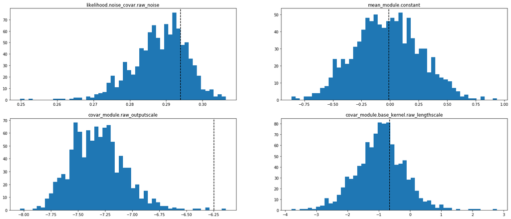

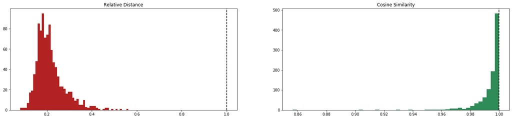

```python
# Mixed of above and below true values
check_theta(noise = 0.2, outputscale = 3, lengthscale = 1)
```

```
Using m = 10
True Gradient = tensor([-3.2879e-01, -5.9947e-03, -1.1138e+01,  6.3872e+00])
```

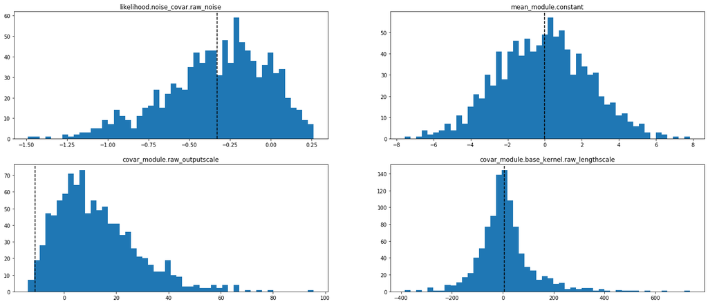

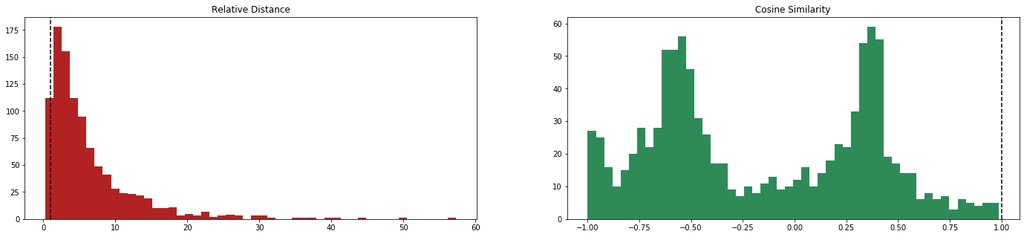

```python
# Above true values
k = 1.5
check_theta(k*noise_true, k*outputscale_true, k*lengthscale_true)
```

```
Using m = 10
True Gradient = tensor([-1.6809e-01, -3.0345e-02, -9.8264e+01,  3.8181e-01])
```

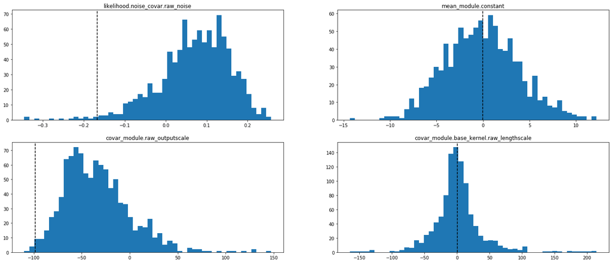

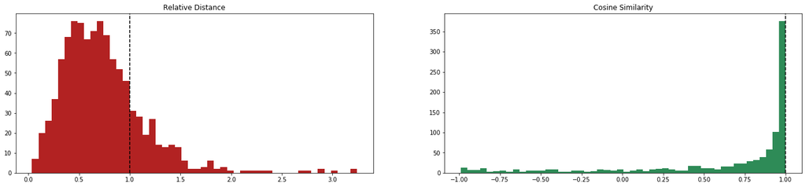

```python
# Below true values
k = 0.5
check_theta(k*noise_true, k*outputscale_true, k*lengthscale_true)
```

Discussion

- Both the subsampled and full gradients are scaled by the sample size
- The gradient does appear to be biased. The means of these distributions don't always appear by the vertical dotted line where they should be.
- Cosine similarity is good for first and third plots, but second one is wild.

# Plotting Bias vs Parameters

Here, we separately vary each parameter. For each value, we average all of the subsampled gradients, and compute the cosine similarity and relative distance compared to the true gradient at that parameter.

```python
# Parameters to examine
noises = torch.linspace(0.05, 0.15)      # Truly 0.1
outputscales = torch.linspace(3, 5)      # Truly 4
lengthscales = torch.linspace(1.5, 2.5)  # Truly 2
```

```python
def bias_measures(par_dict, aux_pars, true_par = None, k = 100):

    # Processing and validating parameter to vary
    par_name, = list(par_dict.keys())
    pars = par_dict[par_name]
    if par_name not in ['noise', 'outputscale', 'lengthscale']:
        raise ValueError(f'Parameter name {par_name} invalid')

    # Cosine similarity object and storage for the measures
    cos = torch.nn.CosineSimilarity(dim = -1)
    cos_sims, r_dists = [], []

    # Computing measures
    for par in tqdm(pars):
        super_model = SuperModel(X, Y)
        super_model.set_parameters(**{**{par_name: par}, **aux_pars})
        nL = super_model.gradient(X, Y)
        nLms = super_model.mini_gradient(X, Y, k = k)
        mean_nLm = torch.mean(torch.stack(nLms), dim = 0)
        cos_sims.append(cos(nL, mean_nLm))
        r_dists.append(relative_distance(nL, mean_nLm))

    # Plotting
    fig, ax1 = plt.subplots(figsize = (8, 4))
    ax1.set_xlabel(par_name)
    # Cosine similarity
    cos_color = 'red'
    ax1.set_ylabel('Cosine Similarity', color = cos_color)
    ax1.plot(pars, cos_sims, color = cos_color)
    ax1.tick_params(axis = 'y', labelcolor = cos_color)
    # Relative distance
    ax2 = ax1.twinx()  # instantiate a second axes that shares the same x-axis
    r_dist_color = 'blue'
    ax2.set_ylabel('Relative Distance', color = r_dist_color)  # we already handled the x-label with ax1
    ax2.plot(pars, r_dists, color = r_dist_color)
    ax2.tick_params(axis = 'y', labelcolor = r_dist_color)
    # Vertical line at true parameter value
    if true_par is not None:
        ax1.axvline(true_par, color = 'black', linestyle = 'dashed')
    # Display
    fig.tight_layout()  # otherwise the right y-label is slightly clipped
    plt.show()
```

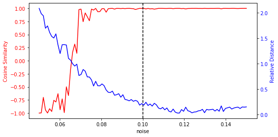

```python
bias_measures({'noise':noises}, {'outputscale':outputscale_true, 'lengthscale':lengthscale_true}, true_par = noise_true)
```

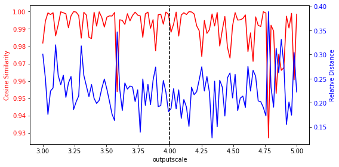

```python
bias_measures({'outputscale':outputscales}, {'noise':noise_true, 'lengthscale':lengthscale_true}, true_par = outputscale_true)
```

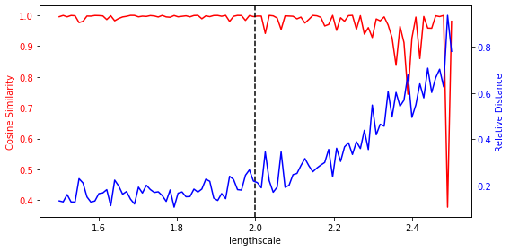

```python
bias_measures({'lengthscale':lengthscales}, {'noise':noise_true, 'outputscale':outputscale_true}, true_par = lengthscale_true)
```